# Modelos

## USO DE MODELOS

### Búsqueda de OUTLIERS (datos anomálos)

- Se ha realizado un diagrama de caja para el conjunto de nuestro dataset

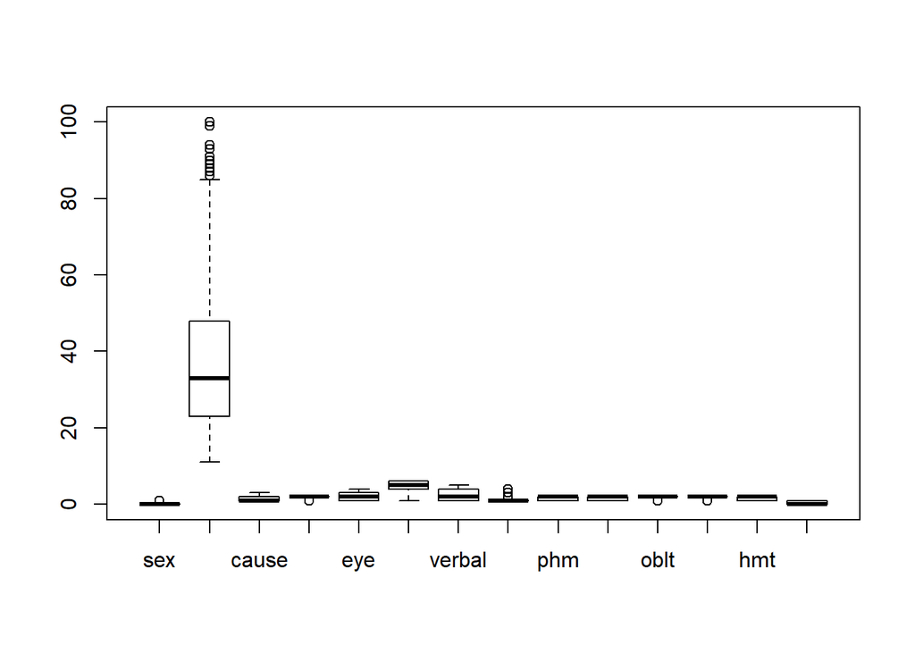

- Nos hemos dado cuenta que existen numerosos datos anomalos “Outliers” en la variable de edad.

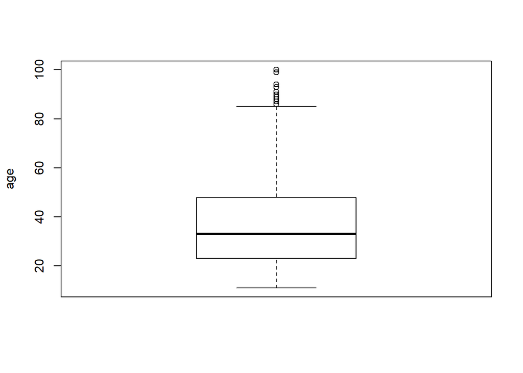

- Estos son las edades anomalas:

```
##  [1]  86  86  86  86  86  86  87  87  87  87  88  88  88  88  89  89  90
## [18]  91  91  91  93  93  94  86  86  86  86  86  86  86  87  87  87  87
## [35]  87  87  87  88  88  88  88  89  89  89  89  89  89  89  90  90  91
## [52]  91  93  94  99 100
```

- Antes de proceder a eliminar los datos anomalos, vamos a ver la correlacion existente con la variable de *“Outcome”*:

```
## [1] 0.2598931
```

- Tambien vamos a observar como es la media y la mediana:
  - Media

  ```
  ## [1] 37.02119
  ```

  - Mediana

  ```
  ## [1] 33
  ```

- Por tanto, hemos creado una funcion que nos elimine directamente los datos anomalos, es decir, todos aquellos datos que no se encuentren en el rango Q1-1.5·RIC o superiores a Q3+1.5·RIC se eliminaran. Siendo RIC el rango intercuartil (Q1-Q3)

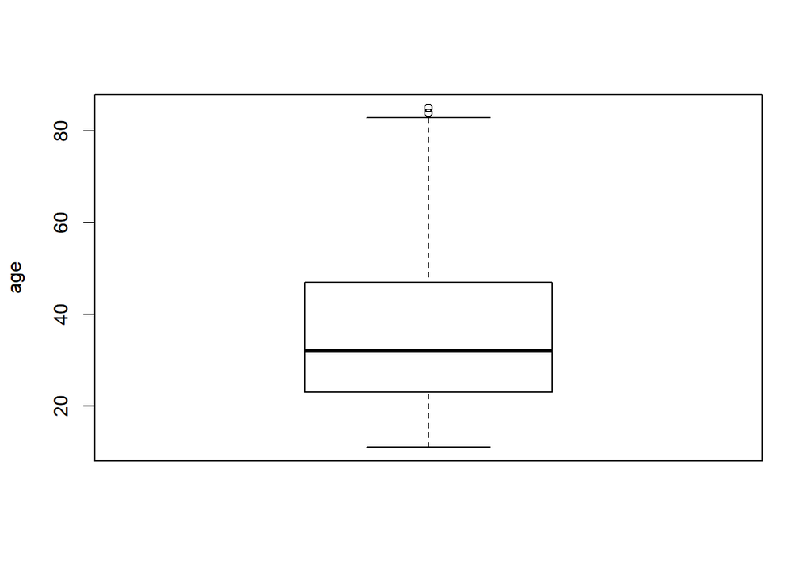

- Ahora veamos la correlacion posterior a la eliminacion de los datos anomalos con la variable de *“Outcome”*;

```
## [1] 0.2452825
```

- Vemos que la correlacion ha empeorado un poco. De todas formas la correlacion entre la edad y el *“outcome”* es bastante debil.
- Tambien vamos a observar como es la media y la mediana:
  - Media

  ```
  ## [1] 36.60303
  ```

  - Mediana

  ```
  ## [1] 32
  ```

- Como se puede comprobar, la eliminación de los *outliers* no ha afectado demasiado a las variables estadisticos por lo que no existe motivo para su eliminación.
- Por otro lado es necesario destacar que estos pacientes cuya edad es anomala (estadísticamente), en la naturaleza tampoco se consideran pacientes anomalos, ya que se encuentran en un rango de edades en las que sufrir un traumatismo craneocefálico es totalmente posible.

### ANÁLISIS DE NORMALIDAD

- En primer lugar, visualizaremos la densidad de nuestras variables (individualmente), con el objetivo de observar a simple vista si cumplen o no con una distribucion normal.

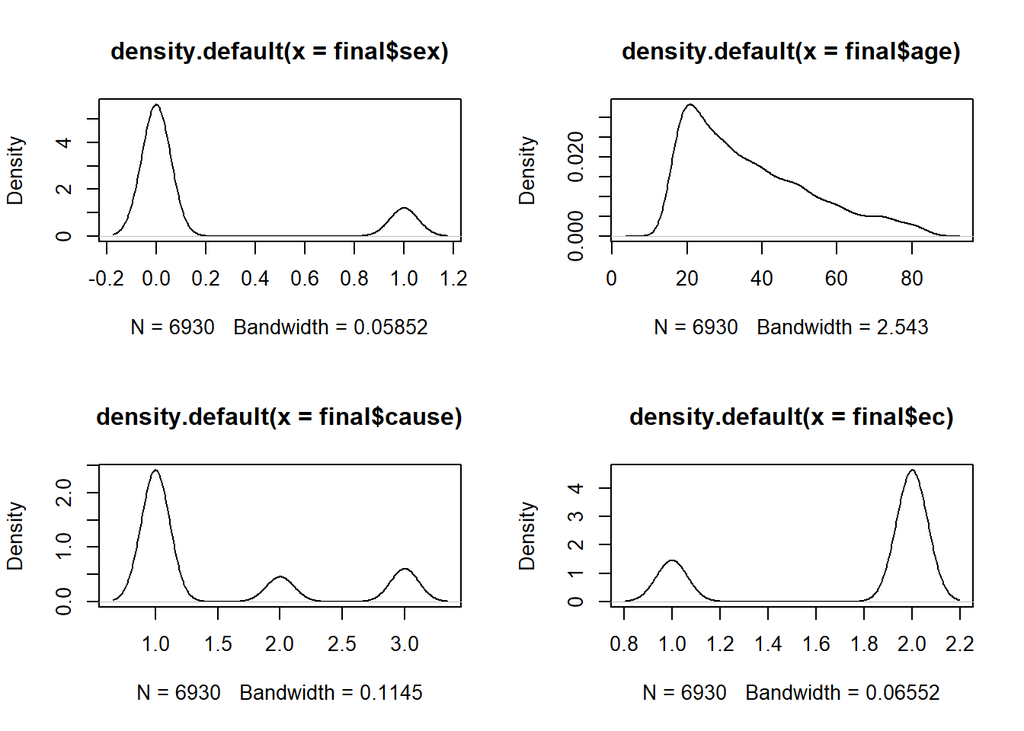

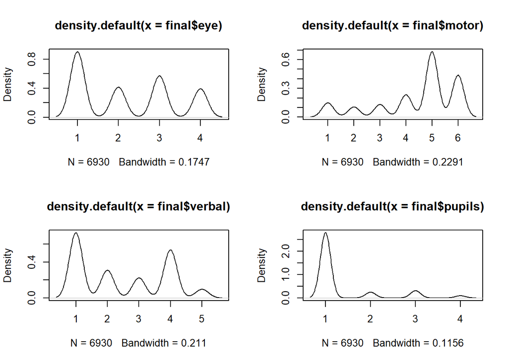

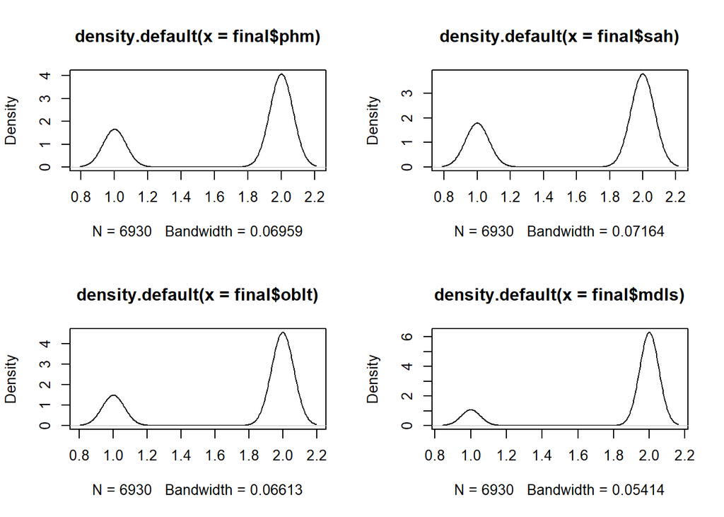

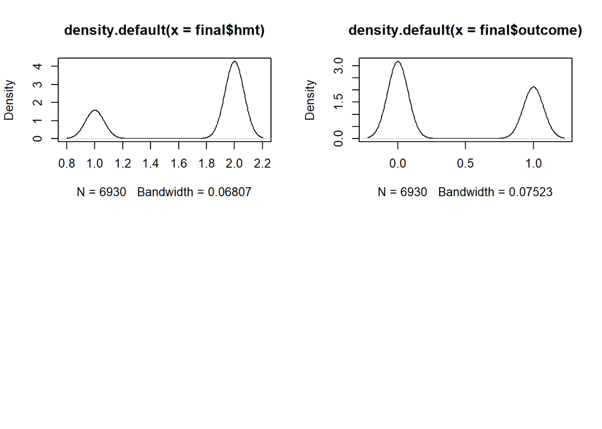

### Estudio de correlación

- Para el estudio de la correlacion, utilizaremos el **coeficiente de correlacion de Pearson (R)**. Mediante el siguiente grafico, vamos a observar las relaciones que tienen los pares de variables entre si.

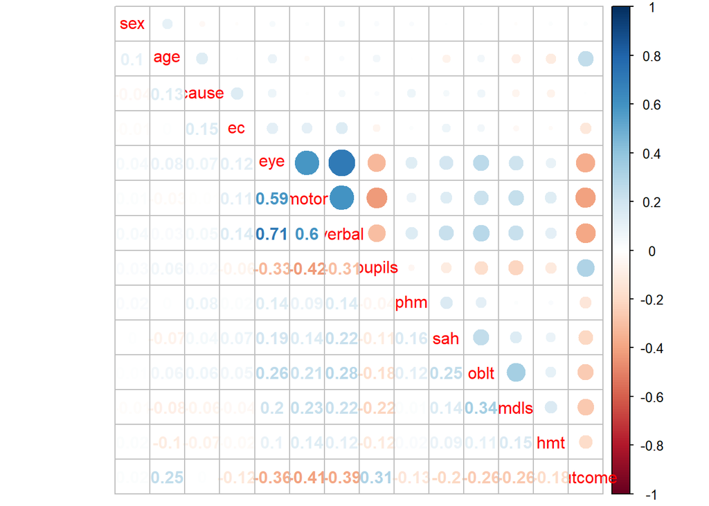

- En este grafico podemos observar como por ejemplo las variables de *“motor”*, *“verbal”* y *“eye”* tienen bastante relacion y dependencia entre si. Sin embargo hay algo que no nos cuadra y es que no existe una gran dependencia entre la variable “age” y la variable de “outcome”, aspecto que podria ser mas sustancial en la naturaleza.
- Teniendo en cuenta los valores de la variable *“outcome”* (1 fallece y 0 vive), la correlacion negativa de las variable del test de glasgow (eye, motor, verbal) tiene sentido, puesto que en general, cuanto mayor sea el valor de estas variables, mejor pronostico de vida hay. La variable de “pupils” es al contrario, cuanto mayores sean sus valores, mas probable es el pronostico de fallecimiento.

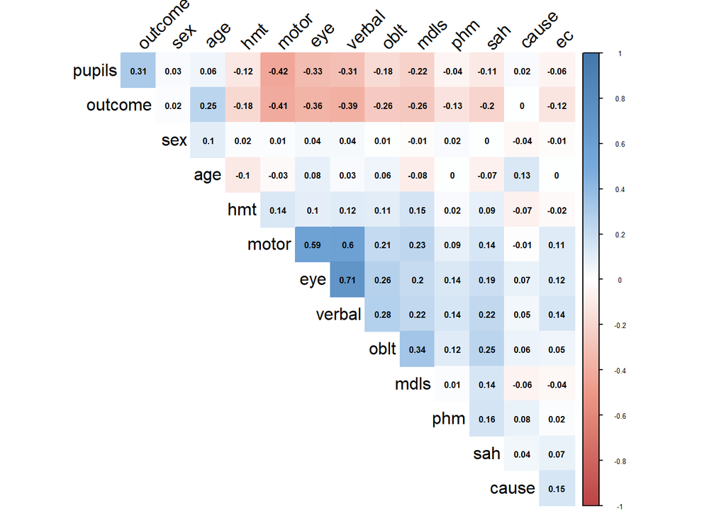

- Como se ha podido apreciar en las 2 graficas anteriores, existe una gran correlacion entre las variables *“motor”*, *“eye”* y *“verbal”*.

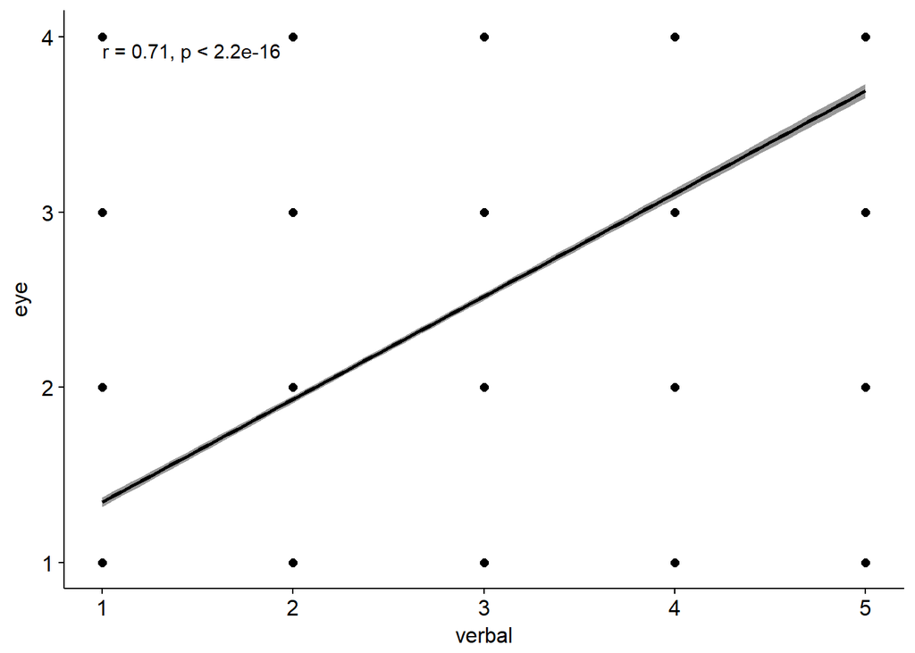

- En la grafica anterior podemos volver a comprobar que existe una gran relacion lineal positiva entre las variables mas correlacionadas que son “verbal” y “eye”.
- Matriz de Correlaciones Parciales

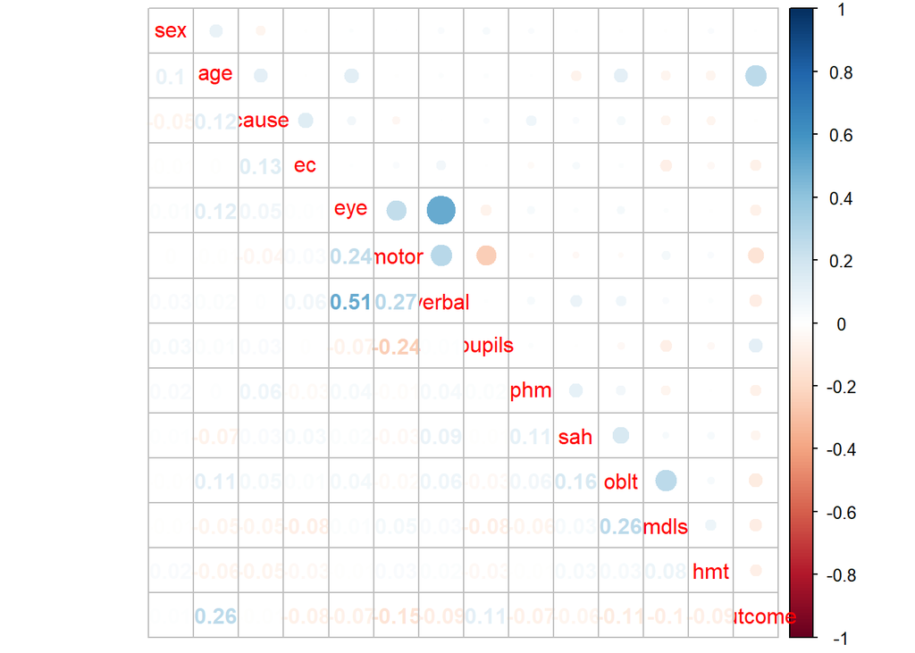

- Con la matriz de correlaciones parciales, obtendremos las correlaciones parciales que existe entre los pares de variables eliminando el efecto de las restantes. Vemos que las correlaciones fuertes se encuentran entre los mismos pares de variables que en la matriz de correlación total.
- A continuación, a modo de información, se muestra un listado en orden descendente con las mayores correlaciones existentes:

```
##     First.Variable Second.Variable Correlation
## 89             eye          verbal   0.7088056
## 90           motor          verbal   0.5989863
## 75             eye           motor   0.5863534
## 104          motor          pupils  -0.4224881
## 188          motor         outcome  -0.4098411
## 189         verbal         outcome  -0.3893489
## 187            eye         outcome  -0.3618281
## 165           oblt            mdls   0.3377311
## 103            eye          pupils  -0.3254853
## 190         pupils         outcome   0.3099949
## 105         verbal          pupils  -0.3073014
## 147         verbal            oblt   0.2765892
## 194           mdls         outcome  -0.2634093
## 145            eye            oblt   0.2609820
## 193           oblt         outcome  -0.2570853
```

- Las correlaciones entre las variables y la clase ordenadas en orden descendente son las siguientes:

```
##     First.Variable Second.Variable Correlation
## 188          motor         outcome -0.40984112
## 189         verbal         outcome -0.38934889
## 187            eye         outcome -0.36182805
## 190         pupils         outcome  0.30999486
## 194           mdls         outcome -0.26340926
## 193           oblt         outcome -0.25708526
## 184            age         outcome  0.24528254
## 192            sah         outcome -0.20016386
## 195            hmt         outcome -0.18246423
## 191            phm         outcome -0.13254914
## 186             ec         outcome -0.12180868
## 183            sex         outcome  0.01988148
## 185          cause         outcome  0.00362152
## 196        outcome         outcome  0.00000000
```

- Por consiguiente consideramos que aunque exista una correlacion importante entre las variables “eye”, “verbal” y “motor”, no es lo suficientemente fuerte como para concluir que estas variables contienen la misma informacion y sea necesario la eliminacion de algunas de ellas. Por lo que no se procede a descartar ninguna de estas variables en estudios posteriores.

# Selección de variables con más importancia.

## Uso de “Random Forest”

- En este apartado, se buscara obtener un listado con las variables mas importantes, usando el algoritmo de *“Random Forest”* para posteriormente tener en cuenta posibles descartes de variables en estudios posteriores.
- La idea que existe detras de los *“Random Forest”* es generar un numero importante de arboles, entrenarlos y calcular el promedio de su salida.
- En cada iteracion del algoritmo de *“Random Forest”* se genera un error conocido como **OOB**, este error ira aumentando o disminuyendo en cada iteracion y por cada variable que se incluya en el algoritmo.
- En cada paso (nodo) se recalcula el conjunto de **“m”** predictores permitidos. Lo más típico es elegir la raiz cuadrada del numero total de variables.En nuestro caso, contamos con un total de 13 variables, por lo que se escogerian 4 variables (redondeando hacia arriba en caso de no ser un número entero) en el caso de **árboles de clasificación** y **m=p/3** en el caso de **árboles de regresión**. Siendo **“p”** el numero de variables.
- Aun asi, es necesario calcular la variable **“mtry”**, puesto que es el único parámetro ajustable al cual los bosques aleatorios son algo sensibles. El “mtry” es el número de variables aleatorias utilizadas en cada árbol. La reduccion del “mtry” reduce tanto la correlación como la fuerza, aumentando ambas en caso contrario.
- En algún punto intermedio hay un rango “óptimo” de “mtry”, generalmente bastante ancho.Usando la tasa de error de OOB, se puede encontrar rápidamente un valor de mínimo en el rango.

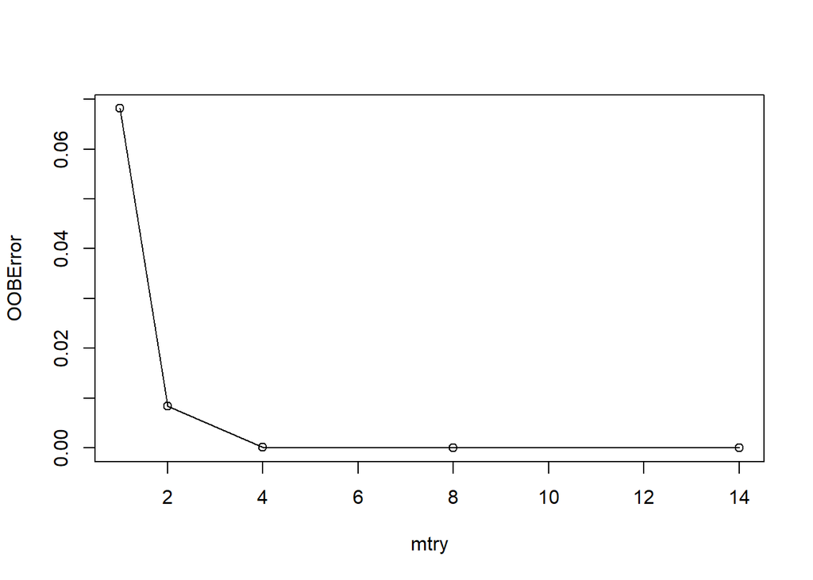

```
##    mtry     OOBError
## 1     1 6.815227e-02
## 2     2 8.410457e-03
## 4     4 1.860384e-04
## 8     8 9.455999e-07
## 14   14 1.516152e-07
```

- Como se puede comprobar, el error OOB, se estabiliza, indicando cuantas particiones se deben realizar para obtener los mejores resultados En este caso, con **4 variables sería suficiente** (puesto que es el numero donde se estabiliza el error OOB).
- Las variables mas importantes utilizando el “mtry” son las siguientes:

```
##         X.IncMSE IncNodePurity
## sex     3.644135      42.74758
## cause   5.053846      67.53416
## phm    13.376213      50.51834
## hmt    19.280205      46.15191
## sah    25.503434      49.90204
## ec     27.088617      48.87114
## mdls   37.442228      40.09944
## oblt   41.338194      49.24964
## pupils 44.907660      75.75228
## eye    46.159085     101.89543
## verbal 65.012768     178.64825
## motor  67.412261     259.78320
## age    72.581717     426.58730
```

- La variable **“IncNodePurity”** se la conoce tambien como la media de decrecimiento de de Gini. El indice de Gini es una “medida de desorden” en este caso *“IncNodePurity”* tiene el siguiente sentido, a mayor medida, mayor importancia en los modelos creados, puesto que valores proximos a 0 implican un mayor desorden. Por tanto, si computamos la media del “decrecimiento” del indice de Gini cuanto mayor sea esta medida, mas variabilidad aporta a la variable dependiente.
- Por otro lado, la variable **“IncMSE”** es la media de decrecimiento en la precision, y es tambien un indicador sobre la importancia de las variables en el modelo.
- El siguiente grafico representa la importancia de las variables segun su media y los valores de *“Random Forest”* mostrados anteriormente:

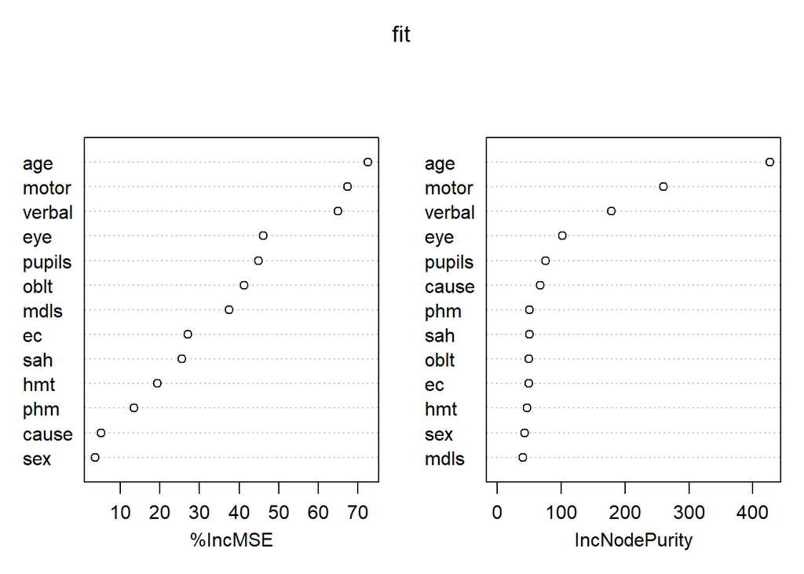

- A continuacion se va a utilizar un arbol de clasificación, que nos mostrara la importancia de las variables segun este algoritmo de clasificacion.

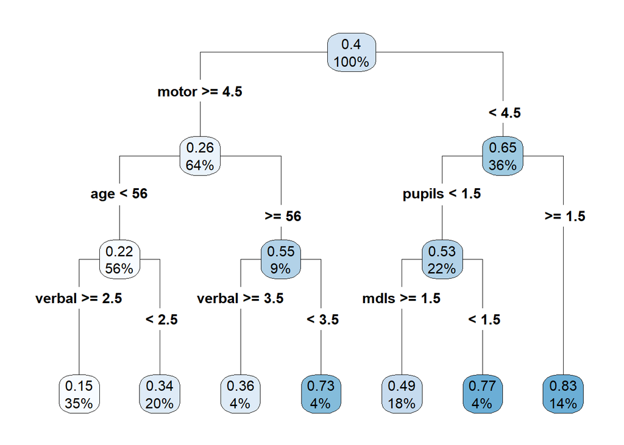

```
## n= 6930
##
## node), split, n, deviance, yval
##       * denotes terminal node
##
##  1) root 6930 1664.39500 0.4008658
##    2) motor>=4.5 4458  864.83090 0.2633468
##      4) age< 56.5 3861  661.19090 0.2193732
##        8) verbal>=2.5 2445  306.28790 0.1468303 *
##        9) verbal< 2.5 1416  319.81920 0.3446328 *
##      5) age>=56.5 597  147.88940 0.5477387
##       10) verbal>=3.5 296   68.32095 0.3614865 *
##       11) verbal< 3.5 301   59.20266 0.7308970 *
##    3) motor< 4.5 2472  563.21680 0.6488673
##      6) pupils< 1.5 1504  374.27060 0.5339096
##       12) mdls>=1.5 1260  314.79680 0.4873016 *
##       13) mdls< 1.5 244   42.60246 0.7745902 *
##      7) pupils>=1.5 968  138.18900 0.8274793 *
```

- Si recordamos, un resultado en el *“outcome”* de 0 eran aquellos pacientes que a los 6 meses habian vivido mientras quen un resultado de 1, significaba que los pacientes fallecian.Teniendo en cuenta este dato, podemos observar que los nodos del arbol son aquellas variables que el algoritmo considera mas relevantes y que hacen que un paciente viva o fallezca.
- La interpretacion que se da al arbol es la siguiente: Cada nodo contiene el porcentaje de informacion que contiene ademas de la media de la variable *“outcome”* en cada particion. Por ejemplo, la media de *“outcome”* es de 0.4, que coincide con el 0.4 del nodo raiz. Sin embargo, cuando la variable *“motor”* es mayor de 4.5, entonces el numero de datos se reduce al 64% y la media de *“outcome”* se vuelve a 0.26, significando para este caso que la mayoria de los pacientes viven, puesto que se aproxima a 0.
- Como conclusiones, utilizaremos las variables que se han considerado como mas importantes en el algoritmo del arbol de clasificacion y son las siguientes: *“motor”*,*“age”*, *“pupils”*,*“verbal”* y *“mdls”*.

## Uso del método de regresión paso a paso (Stepwise Regression)

- Este método es uno de los que se utilizan en la seleccion algoritmica del modelo. Se utiliza para identificar aquellas variables que se deberan integrar o no en los modelos a estudiar.

*La logica subyaciente de este algoritmo consiste en conservar las variables independientes que contienen informacion relevante y a la vez prescindir de aquellas que resulten redundantes respecto de las que quedaron en el modelo.

```
##
## Call:
## glm(formula = outcome ~ ., family = binomial, data = final)
##
## Deviance Residuals:
##     Min       1Q   Median       3Q      Max
## -2.7765  -0.7606  -0.3985   0.7762   2.6408
##
## Coefficients:
##              Estimate Std. Error z value Pr(>|z|)
## (Intercept)  5.054157   0.310487  16.278  < 2e-16 ***
## sex          0.041738   0.080207   0.520    0.603
## age          0.041875   0.001976  21.187  < 2e-16 ***
## cause       -0.024701   0.040518  -0.610    0.542
## ec          -0.437802   0.069418  -6.307 2.85e-10 ***
## eye         -0.237643   0.038838  -6.119 9.43e-10 ***
## motor       -0.289910   0.025841 -11.219  < 2e-16 ***
## verbal      -0.237017   0.032541  -7.284 3.25e-13 ***
## pupils       0.378928   0.043887   8.634  < 2e-16 ***
## phm         -0.394038   0.065282  -6.036 1.58e-09 ***
## sah         -0.279699   0.065385  -4.278 1.89e-05 ***
## oblt        -0.638613   0.073955  -8.635  < 2e-16 ***
## mdls        -0.709317   0.091718  -7.734 1.04e-14 ***
## hmt         -0.488884   0.067500  -7.243 4.40e-13 ***
## ---
## Signif. codes:  0 '***' 0.001 '**' 0.01 '*' 0.05 '.' 0.1 ' ' 1
##
## (Dispersion parameter for binomial family taken to be 1)
##
##     Null deviance: 9332.8  on 6929  degrees of freedom
## Residual deviance: 6751.1  on 6916  degrees of freedom
## AIC: 6779.1
##
## Number of Fisher Scoring iterations: 4
```

```
## Stepwise Model Path
## Analysis of Deviance Table
##
## Initial Model:
## outcome ~ sex + age + cause + ec + eye + motor + verbal + pupils +
##     phm + sah + oblt + mdls + hmt
##
## Final Model:
## outcome ~ age + ec + eye + motor + verbal + pupils + phm + sah +
##     oblt + mdls + hmt
##
##
##      Step Df  Deviance Resid. Df Resid. Dev      AIC
## 1                           6916   6751.097 6779.097
## 2   - sex  1 0.2704474      6917   6751.368 6777.368
## 3 - cause  1 0.4047151      6918   6751.772 6775.772
```

- Una vez mas podemos comprobar que las variables de *“cause”* y *“sex”* son las que se descartan usando este algoritmo.

# Analisis de PCA

```
## Importance of components:
##                            PC1    PC2     PC3     PC4     PC5    PC6
## Standard deviation     16.5659 2.0860 0.96050 0.76858 0.68086 0.6514
## Proportion of Variance  0.9713 0.0154 0.00327 0.00209 0.00164 0.0015
## Cumulative Proportion   0.9713 0.9867 0.98999 0.99208 0.99373 0.9952
##                            PC7    PC8     PC9    PC10    PC11   PC12
## Standard deviation     0.51378 0.4441 0.42801 0.41667 0.40227 0.3766
## Proportion of Variance 0.00093 0.0007 0.00065 0.00061 0.00057 0.0005
## Cumulative Proportion  0.99616 0.9969 0.99751 0.99812 0.99870 0.9992
##                           PC13    PC14
## Standard deviation     0.37091 0.29861
## Proportion of Variance 0.00049 0.00032
## Cumulative Proportion  0.99968 1.00000
```

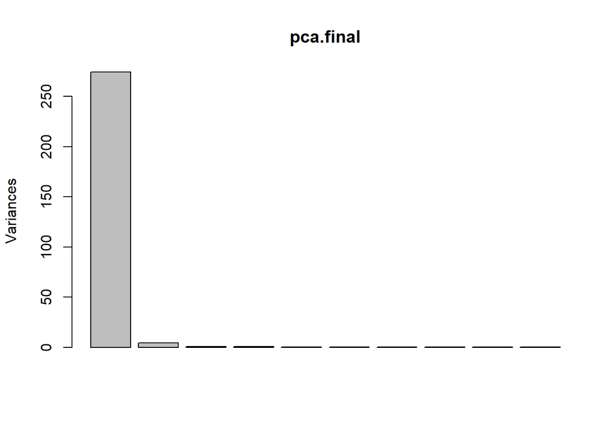

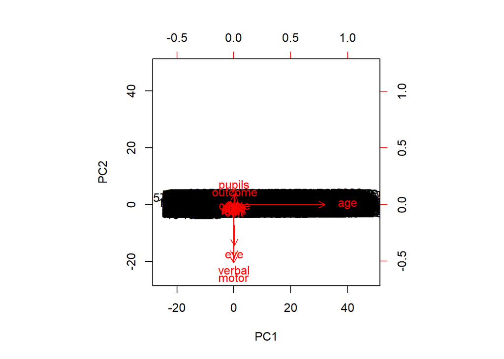

- Como se puede comprobar en la grafica anterior, al no haber escalado las variables, la primera componente principal (PC1) esta dominada por la variable *“age”*, mientras que la segunda componente principal esta dominada por las variables: *“eye”*, *“motor”* y *“verbal”*.
- Ahora vamos a utilizar la **matriz de covarianza**, habiendo normalizado todas las variables.

```
## Importance of components:
##                           PC1    PC2     PC3     PC4     PC5     PC6
## Standard deviation     0.7051 0.4706 0.45354 0.42754 0.41448 0.39605
## Proportion of Variance 0.2351 0.1047 0.09728 0.08644 0.08124 0.07418
## Cumulative Proportion  0.2351 0.3398 0.43709 0.52353 0.60477 0.67895
##                            PC7     PC8     PC9    PC10    PC11    PC12
## Standard deviation     0.39038 0.37255 0.35681 0.29999 0.23364 0.20575
## Proportion of Variance 0.07207 0.06564 0.06021 0.04256 0.02582 0.02002
## Cumulative Proportion  0.75101 0.81665 0.87686 0.91941 0.94523 0.96525
##                           PC13    PC14
## Standard deviation     0.19667 0.18658
## Proportion of Variance 0.01829 0.01646
## Cumulative Proportion  0.98354 1.00000
```

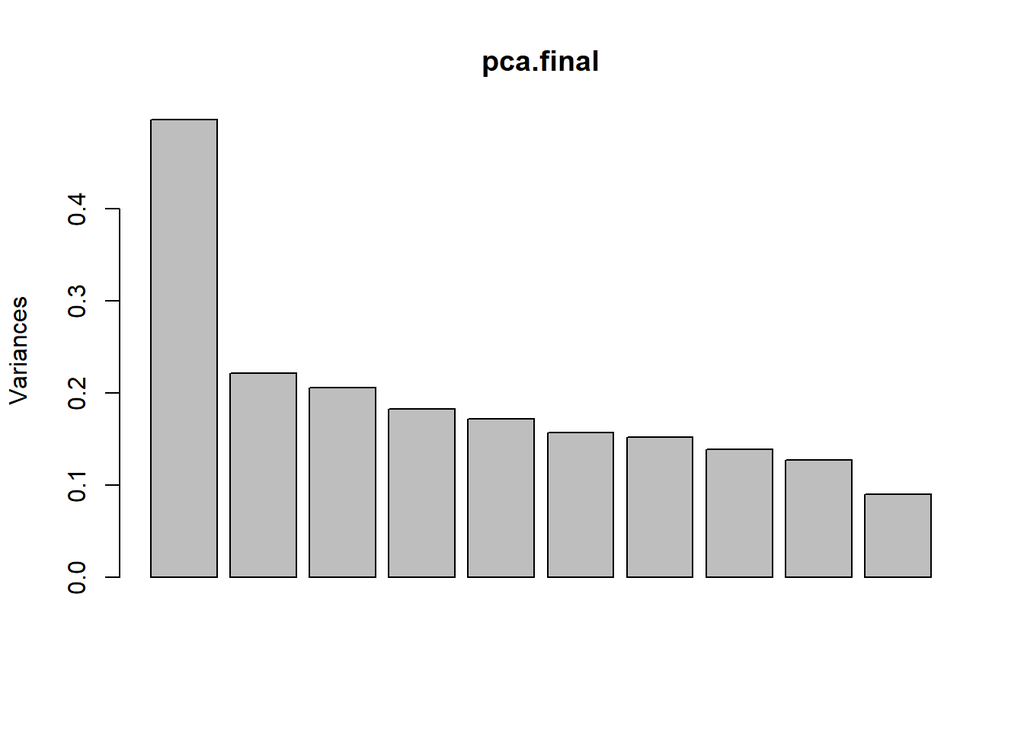

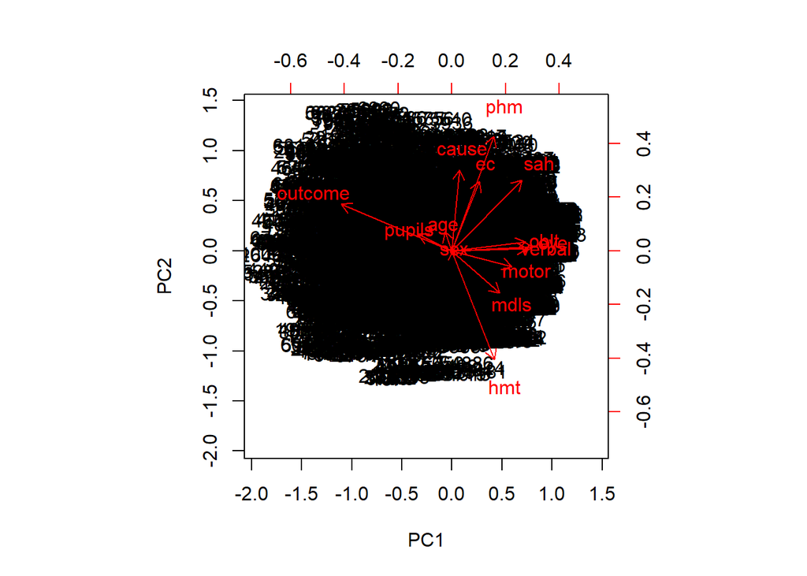

  ```
  ##  [1] 0.49713279 0.22143722 0.20570161 0.18278879 0.17178962 0.15685861
  ##  [7] 0.15239376 0.13879386 0.12731397 0.08999118 0.05458915 0.04233462
  ## [13] 0.03867736 0.03481073
  ```

  ```
  ##        eigenvalue variance.percent cumulative.variance.percent
  ## Dim.1  0.49713279        23.509395                    23.50940
  ## Dim.2  0.22143722        10.471760                    33.98115
  ## Dim.3  0.20570161         9.727623                    43.70878
  ## Dim.4  0.18278879         8.644076                    52.35285
  ## Dim.5  0.17178962         8.123926                    60.47678
  ## Dim.6  0.15685861         7.417839                    67.89462
  ## Dim.7  0.15239376         7.206697                    75.10132
  ## Dim.8  0.13879386         6.563557                    81.66487
  ## Dim.9  0.12731397         6.020674                    87.68555
  ## Dim.10 0.08999118         4.255680                    91.94123
  ## Dim.11 0.05458915         2.581520                    94.52275
  ## Dim.12 0.04233462         2.002003                    96.52475
  ## Dim.13 0.03867736         1.829051                    98.35380
  ## Dim.14 0.03481073         1.646198                   100.00000
  ```

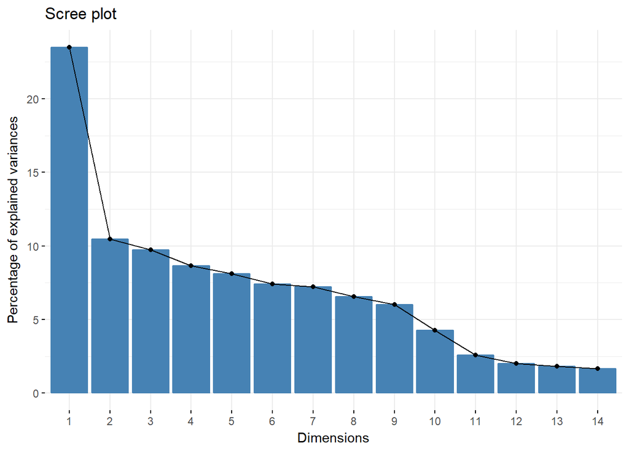

```
##                 PC1          PC2         PC3         PC4         PC5
## sex      0.00754185  0.004825702 -0.05061100  0.09673923 -0.08169835
## age     -0.03305719  0.089077063  0.02955650 -0.01094135 -0.09084363
## cause    0.03634525  0.376804210  0.18316340 -0.09565336  0.12960828
## ec       0.12719737  0.321982271  0.52579134 -0.25862893  0.53735713
## eye      0.37584853  0.019196020  0.23805982  0.11908233 -0.21180882
## motor    0.27860212 -0.072483884  0.17979746  0.09522108 -0.10943985
## verbal   0.35002340  0.010691932  0.18829500  0.08182141 -0.15454678
## pupils  -0.15858549  0.076136117 -0.06963948 -0.02843065  0.05073360
## phm      0.19546358  0.532494470 -0.37457091  0.67612986  0.14592864
## sah      0.32519856  0.328128704 -0.48960240 -0.55085227  0.09217214
## oblt     0.34248291  0.040645898 -0.19093528 -0.28120171 -0.30335822
## mdls     0.22183247 -0.197257325 -0.10251020 -0.10980630 -0.19521708
## hmt      0.19633261 -0.505774550 -0.31239966  0.05260687  0.65098174
## outcome -0.51555059  0.217405899 -0.18078512 -0.17100730 -0.11188899
##                  PC6          PC7         PC8          PC9        PC10
## sex      0.468631120 -0.545637298  0.56848224 -0.362100975  0.05449783
## age      0.213465260 -0.004555270 -0.05438566  0.015539408 -0.06192319
## cause    0.266773385  0.351493551 -0.30349198 -0.693069485  0.13967486
## ec       0.075208510 -0.005328975  0.31834880  0.361266429  0.09920550
## eye      0.216580398 -0.199155308 -0.32508940  0.111568280 -0.05697973
## motor    0.059764349 -0.130958699 -0.16923921  0.085139555  0.03200627
## verbal   0.158055809 -0.182516720 -0.24157401  0.110972727 -0.03748816
## pupils   0.012761929  0.016462188  0.05708582 -0.041706107 -0.07740804
## phm     -0.007730786  0.116800019  0.08439404  0.173756733  0.08844781
## sah     -0.230815829 -0.386705035 -0.15835007 -0.053806287  0.02958798
## oblt     0.305400757  0.515894927  0.33718561  0.134660703 -0.41366626
## mdls     0.047519909  0.225944825  0.14468847  0.082413000  0.86550643
## hmt      0.374508857  0.059210871 -0.18071620  0.002877392 -0.06071833
## outcome  0.541525055 -0.066325752 -0.29153155  0.407445568  0.13989249
##                 PC11         PC12         PC13         PC14
## sex     -0.046320481  0.051178890 -0.043546584  0.008349846
## age      0.064650181 -0.794933844  0.526023857 -0.127687713
## cause   -0.058199593  0.082271746 -0.018041653  0.006485046
## ec       0.007524695 -0.018597326 -0.011587465  0.011292569
## eye      0.283758366 -0.264686334 -0.509573504  0.352793604
## motor   -0.444932122  0.256671073  0.528239380  0.513066463
## verbal   0.222888103  0.350653837  0.224483179 -0.676707194
## pupils   0.791456558  0.250663510  0.353092549  0.368086924
## phm     -0.024586186 -0.001250305  0.003211589  0.006193667
## sah     -0.020857062 -0.040982217  0.022648597  0.025366341
## oblt    -0.045305471  0.083331468 -0.030150696  0.035015405
## mdls     0.134062896 -0.046673682  0.029152475  0.008125267
## hmt      0.024565131 -0.026644622  0.008717377  0.001351517
## outcome -0.118307105  0.158441132 -0.069394421  0.018965211
```